# Meta LOMG (USmerged + Itals) HLA analysis

**Start date:** 05-05-2021

**End date:** 05-05-2021

**Analysed by:** Ruth Chia

**Working directory:** `/data/NDRS_LNG/MyastheniaGravis/updated.April2020/MetaAnalysis.hg38.ByCohort.rerun/HLA/LOMG`

# Table of Contents

## Download code for HATK

HATK(HLA Analysis Tool-Kit) is a collection of tools and modules to perform HLA fine-mapping analysis, which is to identify which HLA allele or amino acid position of the HLA gene is driving the disease

```python
!git clone https://github.com/WansonChoi/HATK.git
```

```
Cloning into 'HATK'...
remote: Enumerating objects: 2246, done.
remote: Counting objects: 100% (206/206), done.
remote: Compressing objects: 100% (135/135), done.
remote: Total 2246 (delta 92), reused 163 (delta 66), pack-reused 2040
Receiving objects: 100% (2246/2246), 169.10 MiB | 20.91 MiB/s, done.
Resolving deltas: 100% (1089/1089), done.
Checking out files: 100% (718/718), done.
```

## Meta from Imputation.1000G

### 4field

```python
%%bash
cd HATK

DIR_US="/data/NDRS_LNG/MyastheniaGravis/updated.April2020/US/Imputation.HLA/Imputation.1000G.LOMG/4field"
DIR_Itals="/data/NDRS_LNG/MyastheniaGravis/updated.April2020/Itals/Imputation.HLA/Imputation.1000G.LOMG/4field"

out="/data/NDRS_LNG/MyastheniaGravis/updated.April2020/MetaAnalysis.hg38.ByCohort.rerun/HLA/LOMG"
mkdir $out/1000G
mkdir $out/1000G/4field

python HATK.py \
    --metaanalysis \
    --s1-logistic-result $DIR_US/RESULT_LOMG.USmerged.1000G_REF.EUR.hatk.chr6.4field.hg38.assoc.logistic \
    --s1-bim $DIR_US/RESULT_LOMG.USmerged.1000G_REF.EUR.hatk.chr6.4field.hg38.bim \
    --s2-logistic-result $DIR_Itals/RESULT_LOMG.Itals.1000G_REF.EUR.hatk.chr6.4field.hg38.assoc.logistic \
    --s2-bim $DIR_Itals/RESULT_LOMG.Itals.1000G_REF.EUR.hatk.chr6.4field.hg38.bim \
    --out $out/1000G/4field/RESULT_Meta.LOMG.overall.USmerged.Itals.HLA.hg38
```

```
Namespace(Ggroup=False, HLA=None, NoCaption=False, Pgroup=False, aa=None, ar=None, bmarkergenerator=False, chped=None, condition=None, condition_list=None, covar=None, covar_name=None, dict_AA=None, dict_SNPS=None, fam=None, fourF=False, hat=None, heatmap=False, hg=None, hla2hped=False, hped=None, i…

[HLA_Study.py]: MetaAnalysis result :
/data/NDRS_LNG/MyastheniaGravis/updated.April2020/MetaAnalysis.hg38.ByCohort.rerun/HLA/LOMG/1000G/4field/RESULT_Meta.LOMG.overall.USmerged.Itals.HLA.hg38.meta
```

### 4field-GLM-plink

metal file: `/data/NDRS_LNG/MyastheniaGravis/updated.April2020/MetaAnalysis.hg38.ByCohort.rerun/HLA/LOMG/1000G/4field.GLM/metal.4field-GLM-plink.txt`

```
# THIS SCRIPT EXECUTES AN ANALYSIS OF TWO STUDIES - HLA imputed

# THE RESULTS FOR EACH STUDY ARE STORED IN FILES:
# /data/NDRS_LNG/MyastheniaGravis/updated.April2020/US/Imputation.HLA/Imputation.1000G.LOMG/4field/GLM/toMeta.RESULT_LOMG.USmerged.1000G_REF.EUR.hatk.chr6.4field.hg38.tab
# /data/NDRS_LNG/MyastheniaGravis/updated.April2020/Itals/Imputation.HLA/Imputation.1000G.LOMG/4field/GLM/toMeta.RESULT_LOMG.Itals.1000G_REF.EUR.hatk.chr6.4field.hg38.tab

SCHEME  STDERR
AVERAGEFREQ ON
MINMAXFREQ ON

# LOAD THE FIRST INPUT FILE
# UNCOMMENT THE NEXT LINE TO ENABLE GenomicControl CORRECTION
# GENOMICCONTROL ON

# === DESCRIBE AND PROCESS THE FIRST INPUT FILE ===
MARKER marker
ALLELE EffectAllele OtherAllele
FREQ   Freq_EffectAllele
EFFECT BETA
STDERR SE
PVALUE P
#WEIGHT OBS_CT
PROCESS /data/NDRS_LNG/MyastheniaGravis/updated.April2020/US/Imputation.HLA/Imputation.1000G.LOMG/4field/GLM/toMeta.RESULT_LOMG.USmerged.1000G_REF.EUR.hatk.chr6.4field.hg38.tab

# === DESCRIBE AND PROCESS ADDITIONAL INPUT FILE ===
PROCESS /data/NDRS_LNG/MyastheniaGravis/updated.April2020/Itals/Imputation.HLA/Imputation.1000G.LOMG/4field/GLM/toMeta.RESULT_LOMG.Itals.1000G_REF.EUR.hatk.chr6.4field.hg38.tab

OUTFILE META_LOMG.USmerged.Itals.UNRELATED.hg38.HLA.FreqBoth.glm .tbl
ANALYZE HETEROGENEITY
```

```python
%%bash
out="/data/NDRS_LNG/MyastheniaGravis/updated.April2020/MetaAnalysis.hg38.ByCohort.rerun/HLA/LOMG"
#mkdir $out/1000G/4field.GLM
cd $out/1000G/4field.GLM

module load metal
metal /data/NDRS_LNG/MyastheniaGravis/updated.April2020/MetaAnalysis.hg38.ByCohort.rerun/HLA/LOMG/1000G/4field.GLM/metal.4field-GLM-plink.txt
```

```
MetaAnalysis Helper - (c) 2007 - 2009 Goncalo Abecasis
This version released on 2018-08-28

# This program faciliates meta-analysis of genome-wide association studies.
# Commonly used commands are listed below:
#
# Options for describing input files ...
#   SEPARATOR        [WHITESPACE|COMMA|BOTH|TAB] (default = WHITESPACE)
#   COLUMNCOUNTING   [STRICT|LENIENT]            (default = 'STRICT')
#   MARKERLABEL      [LABEL]                     (default = 'MARKER')
#   ALLELELABELS     [LABEL1 LABEL2]             (default = 'ALLELE1','ALLELE2')
#   EFFECTLABEL      [LABEL|log(LABEL)]          (default = 'EFFECT')
#   FLIP
#
# Options for filtering input files ...
#   ADDFILTER        [LABEL CONDITION VALUE]     (example = ADDFILTER N > 10)
#                    (available conditions are <, >, <=, >=, =, !=, IN)
#   REMOVEFILTERS
#
# Options for sample size weighted meta-analysis ...
#   WEIGHTLABEL      [LABEL]                     (default = 'N')
#   PVALUELABEL      [LABEL]                     (default = 'PVALUE')
#   DEFAULTWEIGHT    [NUMBER]                    (default = 1.0)
#   MINWEIGHT        [NUMBER]                    (default = 1.0)
#
# Options for inverse variance weighted meta-analysis ...
#   STDERRLABEL      [LABEL]                     (default = 'STDERR')
#   SCHEME           [SAMPLESIZE|STDERR]         (default = SAMPLESIZE)
#
# Options to enable tracking of allele frequencies ...
#   AVERAGEFREQ      [ON|OFF]                    (default = OFF)
#   MINMAXFREQ       [ON|OFF]                    (default = OFF)
#   FREQLABEL        [LABEL]                     (default = 'FREQ')
#
# Options to enable tracking of user defined variables ...
#   CUSTOMVARIABLE   [VARNAME]
#   LABEL            [VARNAME] AS [HEADER]
#
# Options to enable tracking of chromosomes and positions ...
#   TRACKPOSITIONS   [ON|OFF]                    (default = OFF
```

[output cut: 46 more lines]

```
## Set output file prefix and suffix to META_LOMG.USmerged.Itals.UNRELATED.hg38.HLA.FreqBoth.glm and .tbl ...
###########################################################################
## Running second pass analysis to evaluate heterogeneity...
## Processing file '/data/NDRS_LNG/MyastheniaGravis/updated.April2020/Itals/Imputation.HLA/Imputation.1000G.LOMG/4field/GLM/toMeta.RESULT_LOMG.Itals.1000G_REF.EUR.hatk.chr6.4field.hg38.tab'
## Processing file '/data/NDRS_LNG/MyastheniaGravis/updated.April2020/US/Imputation.HLA/Imputation.1000G.LOMG/4field/GLM/toMeta.RESULT_LOMG.USmerged.1000G_REF.EUR.hatk.chr6.4field.hg38.tab'

###########################################################################
## Executing meta-analysis ...
## Complete results will be stored in file 'META_LOMG.USmerged.Itals.UNRELATED.hg38.HLA.FreqBoth.glm1.tbl'
## Column descriptions will be stored in file 'META_LOMG.USmerged.Itals.UNRELATED.hg38.HLA.FreqBoth.glm1.tbl.info'
## Completed meta-analysis for 13763 markers!
## Smallest p-value is 4.226e-21 at marker 'AA_DRB1_13_32584346_exon2_S:6:32584346:a:p'

## Clearing all stored statistics ...
# Clearing user defined filters ...
```

```
[+] Loading metal  2018-08-28
```

script to reformat meta output files before plotting: `ReformatMetaResults.addMAF.v2.HLA.R`

```
#!/usr/bin/env Rscript

args <- commandArgs(trailingOnly=TRUE)
if (length(args) != 4) {
  stop("USAGE: Rscript ReformatMetaResults.addMAF.v2.HLA.R args[1] args[2] args[3] args[4]
  where args[1] = metaResults
        args[2] = toMetaInput.US
        args[3] = toMetaInput.Itals
        args[4] = outputFileName")
}

# Load libraries
require(data.table)
require(tidyverse)


# Set variables
metaResults <- args[1]
toMetaInput.US <- args[2]
toMetaInput.Itals <- args[3]
outputFileName <- args[4]

# Read in files and reformat meta
meta0 <- fread(metaResults, header=T)

# make list of variants with chr,pos for merging with meta results
us.list <- fread(toMetaInput.US,header=T) %>%
           select(marker,ID,CHROM,POS,OtherAllele,EffectAllele)
itals.list <- fread(toMetaInput.Itals,header=T) %>%
           select(marker,ID,CHROM,POS,OtherAllele,EffectAllele)
list <- rbind(us.list,itals.list) %>% arrange(CHROM,POS) %>% distinct()

meta <- merge(meta0,list,by.x="MarkerName",by.y="marker",all.x=T)

meta$OA <- tolower(meta$OtherAllele)
meta$EA <- tolower(meta$EffectAllele)
meta$EffectAllele <- ifelse(meta$EA == meta$Allele1, meta$Allele1, meta$Allele2)
meta$OtherAllele <- ifelse(meta$EA == meta$Allele1, meta$Allele2, meta$Allele1)
meta$maf_EA.cases <- ifelse(meta$EA == meta$Allele1, meta$Freq1, 1 - meta$Freq1)
meta$beta <- ifelse(meta$EffectAllele == meta$Allele1, meta$Effect, meta$Effect*-1)

tmp1 <- meta %>% rename(P = `P-value`) %>% filter(P > 0.00000005)
tmp2 <- meta %>% rename(P = `P-value`) %>%
        filter(P < 0.00000005) %>%
        filter(Direction == "--" | Direction == "++")

data <- rbind(tmp1,tmp2) %>%
        mutate(CHROM = as.numeric(gsub("chr","",CHROM), POS = as.numeric(POS))) %>%
        filter(POS != is.na(POS)) %>%
        filter(HetISq <= 80) %>%
        filter(Direction == "--" | Direction == "+-" | Direction == "-+" | Direction == "++") %>%
        select(CHROM,POS,ID,MarkerName,EffectAllele,OtherAllele,maf_EA.cases,beta,StdErr,P,Direction,HetISq) %>%
        arrange(CHROM,POS)

dim(meta0)
dim(meta)
dim(data)

# Get frequency information
us <- fread(toMetaInput.US,header=T) %>%
      select(marker,Freq_EffectAllele,Freq_EffectAllele.CASE,Freq_EffectAllele.CTRL,
             ALLELE_CT,CASE_ALLELE_CT,CTRL_ALLELE_CT,
             EffectAllele_CT,EffectAllele_CT.CASE,EffectAllele_CT.CTRL)
colnames(us)[2:10] <- paste(colnames(us)[2:10],"_US",sep="")

itals <- fread(toMetaInput.Itals,header=T) %>%
         select(marker,Freq_EffectAllele,Freq_EffectAllele.CASE,Freq_EffectAllele.CTRL,
                ALLELE_CT,CASE_ALLELE_CT,CTRL_ALLELE_CT,
                EffectAllele_CT,EffectAllele_CT.CASE,EffectAllele_CT.CTRL)
colnames(itals)[2:10] <- paste(colnames(itals)[2:10],"_Italy",sep="")

both <- merge(us,itals,by="marker")

dim(us)
dim(itals)
dim(both)

both$Freq_EffectAllele <- (both$Freq_EffectAllele_US + both$Freq_EffectAllele_Italy)/2
both$Freq_EffectAllele.CASE <- (both$Freq_EffectAllele.CASE_US + both$Freq_EffectAllele.CASE_Italy)/2
both$Freq_EffectAllele.CTRL <- (both$Freq_EffectAllele.CTRL_US + both$Freq_EffectAllele.CTRL_Italy)/2

both$ALLELE_CT <- both$ALLELE_CT_US + both$ALLELE_CT_Italy
both$ALLELE_CT.CASE <- both$CASE_ALLELE_CT_US + both$CASE_ALLELE_CT_Italy
both$ALLELE_CT.CTRL <- both$CTRL_ALLELE_CT_US + both$CTRL_ALLELE_CT_Italy

both$EffectAllele_CT <- both$EffectAllele_CT_US + both$EffectAllele_CT_Italy
both$EffectAllele_CT.CASE <- both$EffectAllele_CT.CASE_US + both$EffectAllele_CT.CASE_Italy
both$EffectAllele_CT.CTRL <- both$EffectAllele_CT.CTRL_US + both$EffectAllele_CT.CTRL_Italy

both$maf_EA <- both$EffectAllele_CT/both$ALLELE_CT
both$maf_EA.CASE <- both$EffectAllele_CT.CASE/both$ALLELE_CT.CASE
both$maf_EA.CTRL <- both$EffectAllele_CT.CTRL/both$ALLELE_CT.CTRL
write.table(both,"MAF.USmerged.Itals.txt",sep="\t",quote=F,row.names=F,col.names=T)

freq <- both %>%
        select(marker,Freq_EffectAllele,Freq_EffectAllele.CASE,Freq_EffectAllele.CTRL,
              ALLELE_CT,ALLELE_CT.CASE,ALLELE_CT.CTRL,
              EffectAllele_CT,EffectAllele_CT.CASE,EffectAllele_CT.CTRL,
              maf_EA,maf_EA.CASE,maf_EA.CTRL)


# merge formatted meta results with frequency file
tmp <- merge(data,freq,by.x="MarkerName",by.y="marker")
data2 <- tmp %>%
         select(CHROM,POS,ID,MarkerName,EffectAllele,OtherAllele,
                maf_EA,maf_EA.CASE,maf_EA.CTRL,beta,StdErr,P,Direction,HetISq)

write.table(data2,paste(args[4],".filteredDirection.HetISq80.TIDY.v2",".txt",sep=""),quote=F,row.names=F,col.names=T,sep="\t")
```

```python
%%bash
cp ../Overall/ReformatMetaResults.addMAF.v2.HLA.R .

module load R/3.5.2
DIR="/data/NDRS_LNG/MyastheniaGravis/updated.April2020"
out="/data/NDRS_LNG/MyastheniaGravis/updated.April2020/MetaAnalysis.hg38.ByCohort.rerun/HLA/LOMG"

Rscript ReformatMetaResults.addMAF.v2.HLA.R \
$out/1000G/4field.GLM/META_LOMG.USmerged.Itals.UNRELATED.hg38.HLA.FreqBoth.glm1.tbl \
$DIR/US/Imputation.HLA/Imputation.1000G.LOMG/4field/GLM/toMeta.RESULT_LOMG.USmerged.1000G_REF.EUR.hatk.chr6.4field.hg38.tab \
$DIR/Itals/Imputation.HLA/Imputation.1000G.LOMG/4field/GLM/toMeta.RESULT_LOMG.Itals.1000G_REF.EUR.hatk.chr6.4field.hg38.tab \
$out/1000G/4field.GLM/META_LOMG.USmerged.Itals.UNRELATED.hg38.HLA.FreqBoth
```

```
[1] 13763    15
[1] 13763    24
[1] 3517   12
[1] 6759   10
[1] 10828    10
[1] 3823   19
```

```
[-] Unloading gcc  9.2.0  ...
[-] Unloading GSL 2.6 for GCC 9.2.0 ...
[-] Unloading openmpi 4.0.5  for GCC 9.2.0
[-] Unloading ImageMagick  7.0.8  on cn3451
[-] Unloading HDF5  1.10.4
[-] Unloading NetCDF 4.7.4_gcc9.2.0
[-] Unloading pandoc  2.13  on cn3451
[-] Unloading pcre2 10.21  ...
[-] Unloading R 4.0.5
[+] Loading gcc  7.3.0  ...
[+] Loading GSL 2.4 for GCC 7.2.0 ...
[-] Unloading gcc  7.3.0  ...
[+] Loading gcc  7.3.0  ...
[+] Loading openmpi 3.0.2  for GCC 7.3.0
[+] Loading ImageMagick  7.0.8  on cn3451
[+] Loading HDF5  1.10.4
[+] Loading pandoc  2.13  on cn3451
[+] Loading R 3.5.2

The following have been reloaded with a version change:
  1) GSL/2.6_gcc-9.2.0 => GSL/2.4_gcc-7.2.0     3) gcc/9.2.0 => gcc/7.3.0
  2) R/4.0 => R/3.5.2
```

```python
import pandas as pd

pd.read_csv("/data/NDRS_LNG/MyastheniaGravis/updated.April2020/MetaAnalysis.hg38.ByCohort.rerun/HLA/LOMG/1000G/4field.GLM/META_LOMG.USmerged.Itals.UNRELATED.hg38.HLA.FreqBoth.filteredDirection.HetISq80.TIDY.v2.txt",sep="\t").head()
```

|  | CHROM | POS | ID | MarkerName | EffectAllele | OtherAllele | maf_EA | maf_EA.CASE | maf_EA.CTRL | beta | StdErr | P | Direction | HetISq |
| --- | --- | --- | --- | --- | --- | --- | --- | --- | --- | --- | --- | --- | --- | --- |
| 0 | 6 | 29942594 | AA_A_-11_29942594_exon1_L | AA_A_-11_29942594_exon1_L:6:29942594:a:p | p | a | 0.074077 | 0.079812 | 0.073859 | -0.0030 | 0.0803 | 0.970100 | -+ | 0.0 |
| 1 | 6 | 29942594 | AA_A_-11_29942594_exon1_S | AA_A_-11_29942594_exon1_S:6:29942594:p:a | a | p | 0.197295 | 0.225352 | 0.196229 | 0.0540 | 0.0522 | 0.300500 | +- | 0.0 |
| 2 | 6 | 29942594 | AA_A_-11_29942594_exon1_x | AA_A_-11_29942594_exon1_x:6:29942594:a:p | p | a | 0.123218 | 0.145540 | 0.122370 | 0.0793 | 0.0621 | 0.201700 | -- | 0.0 |
| 3 | 6 | 29942582 | AA_A_-15_29942582_exon1_L | AA_A_-15_29942582_exon1_L:6:29942582:a:p | p | a | 0.468279 | 0.483959 | 0.467684 | 0.0886 | 0.0435 | 0.041550 | -- | 0.0 |
| 4 | 6 | 29942582 | AA_A_-15_29942582_exon1_V | AA_A_-15_29942582_exon1_V:6:29942582:a:p | p | a | 0.408503 | 0.370501 | 0.409946 | -0.1329 | 0.0449 | 0.003074 | ++ | 0.0 |

#### plot (use HATK function - to get manhattan and heatmap)

```python
%%bash
# first need to reformat the meta output from plink glm to match the input for HATK
# i.e have column : CHR,SNP,BP,A1,TEST,NMISS,OR,SE,L95,U95,STAT,P

module load R/3.5.2
R --vanilla --no-save

require(data.table)
require(tidyverse)

data <- fread("1000G/4field.GLM/META_LOMG.USmerged.Itals.UNRELATED.hg38.HLA.FreqBoth.filteredDirection.HetISq80.TIDY.v2.txt",header=T)
data1 <- data %>%
         select(CHROM,ID,POS,EffectAllele,beta,StdErr,P) %>%
         mutate(OR = exp(beta)) %>%
         select(-beta)
data1$TEST <- "ADD"
data1$NMISS <- "NA"
data1$L95 <- "NA"
data1$U95 <- "NA"
data1$STAT <- "NA"
data1 <- data1 %>% select(CHROM,ID,POS,EffectAllele,TEST,NMISS,OR,StdErr,L95,U95,STAT,P)
colnames(data1) <- c("CHR","SNP","BP","A1","TEST","NMISS","OR","SE","L95","U95","STAT","P")
head(data1)
write.table(data1,"1000G/4field.GLM/META_LOMG.USmerged.Itals.UNRELATED.hg38.HLA.FreqBoth.filteredDirectionHetISq80MAF001overall.forHATK.assoc.logistic",sep=" ",quote=F,row.names=F,col.names=T)
```

```
R version 3.5.2 (2018-12-20) -- "Eggshell Igloo"
Copyright (C) 2018 The R Foundation for Statistical Computing
Platform: x86_64-pc-linux-gnu (64-bit)

R is free software and comes with ABSOLUTELY NO WARRANTY.
You are welcome to redistribute it under certain conditions.
Type 'license()' or 'licence()' for distribution details.

R is a collaborative project with many contributors.
Type 'contributors()' for more information and
'citation()' on how to cite R or R packages in publications.

Type 'demo()' for some demos, 'help()' for on-line help, or
'help.start()' for an HTML browser interface to help.
Type 'q()' to quit R.

>
> require(data.table)
> require(tidyverse)
>
> data <- fread("1000G/4field.GLM/META_LOMG.USmerged.Itals.UNRELATED.hg38.HLA.FreqBoth.filteredDirection.HetISq80.TIDY.v2.txt",header=T)
> data1 <- data %>%
+          select(CHROM,ID,POS,EffectAllele,beta,StdErr,P) %>%
+          mutate(OR = exp(beta)) %>%
+          select(-beta)
> data1$TEST <- "ADD"
> data1$NMISS <- "NA"
> data1$L95 <- "NA"
> data1$U95 <- "NA"
> data1$STAT <- "NA"
> data1 <- data1 %>% select(CHROM,ID,POS,EffectAllele,TEST,NMISS,OR,StdErr,L95,U95,STAT,P)
> colnames(data1) <- c("CHR","SNP","BP","A1","TEST","NMISS","OR","SE","L95","U95","STAT","P")
> head(data1)
  CHR                       SNP       BP A1 TEST NMISS        OR     SE L95 U95
1   6 AA_A_-11_29942594_exon1_L 29942594  p  ADD    NA 0.9970045 0.0803  NA  NA
2   6 AA_A_-11_29942594_exon1_S 29942594  a  ADD    NA 1.0554846 0.0522  NA  NA
3   6 AA_A_-11_29942594_exon1_x 29942594  p  ADD    NA 1.0825290 0.0621  NA  NA
4   6 AA_A_-15_29942582_exon1_L 29942582  p  ADD    NA 1.0926435 0.0435  NA  NA
5   6 AA_A_-15_29942582_exon1_V 29942582  p  ADD    NA 0.8755526 0.0449  NA  NA
6   6 AA_A_-15_29942582_exon1_x 29942582  p  ADD    NA 1.0825290 0.0621  NA  NA
  STAT        P
1   NA 0.970100
2   NA 0.300500
3   NA 0.201700
4   NA 0.041550
5   NA 0.003074
6   NA 0.201700
> write.table(data1,"1000G/4field.GLM/META_LOMG.USmerged.Itals.UNRELATED.hg38.HLA.FreqBoth.filteredDirectionHetISq80MAF001overall.forHATK.assoc.logistic",sep=" ",quote=F,row.names=F,col.names=T)
>
```

```
[-] Unloading gcc  9.2.0  ...
[-] Unloading GSL 2.6 for GCC 9.2.0 ...
[-] Unloading openmpi 4.0.5  for GCC 9.2.0
[-] Unloading ImageMagick  7.0.8  on cn3451
[-] Unloading HDF5  1.10.4
[-] Unloading NetCDF 4.7.4_gcc9.2.0
[-] Unloading pandoc  2.13  on cn3451
[-] Unloading pcre2 10.21  ...
[-] Unloading R 4.0.5
[+] Loading gcc  7.3.0  ...
[+] Loading GSL 2.4 for GCC 7.2.0 ...
[-] Unloading gcc  7.3.0  ...
[+] Loading gcc  7.3.0  ...
[+] Loading openmpi 3.0.2  for GCC 7.3.0
[+] Loading ImageMagick  7.0.8  on cn3451
[+] Loading HDF5  1.10.4
[+] Loading pandoc  2.13  on cn3451
[+] Loading R 3.5.2

The following have been reloaded with a version change:
  1) GSL/2.6_gcc-9.2.0 => GSL/2.4_gcc-7.2.0     3) gcc/9.2.0 => gcc/7.3.0
  2) R/4.0 => R/3.5.2
```

```python
%%bash
cd HATK/

python HATK.py \
    --manhattan \
    --ar ../1000G/4field.GLM/META_LOMG.USmerged.Itals.UNRELATED.hg38.HLA.FreqBoth.filteredDirectionHetISq80MAF001overall.forHATK.assoc.logistic \
    --imgt 3320 \
    --hg 38 \
    --yaxis-unit 5 \
    --out ../1000G/4field.GLM/META_LOMG.USmerged.Itals.UNRELATED.hg38.HLA.FreqBoth.filteredDirectionHetISq80MAF001overall
```

```
Namespace(Ggroup=False, HLA=None, NoCaption=False, Pgroup=False, aa=None, ar=['../1000G/4field.GLM/META_LOMG.USmerged.Itals.UNRELATED.hg38.HLA.FreqBoth.filteredDirectionHetISq80MAF001overall.forHATK.assoc.logistic'], bmarkergenerator=False, chped=None, condition=None, condition_list=None, covar=None…

[HLA_Study.py]: Manhattan result :
../1000G/4field.GLM/META_LOMG.USmerged.Itals.UNRELATED.hg38.HLA.FreqBoth.filteredDirectionHetISq80MAF001overall.pdf
```

### 4field-GLM-plink-conditional

metal file: `/data/NDRS_LNG/MyastheniaGravis/updated.April2020/MetaAnalysis.hg38.ByCohort.rerun/HLA/LOMG/1000G/4field.GLM/metal.4field-GLM-plink.conditioned.1.txt`

```
# THIS SCRIPT EXECUTES AN ANALYSIS OF TWO STUDIES - HLA imputed

# THE RESULTS FOR EACH STUDY ARE STORED IN FILES:
# /data/NDRS_LNG/MyastheniaGravis/updated.April2020/US/Imputation.HLA/Imputation.1000G.LOMG/4field/GLM.conditional/toMeta.RESULT_LOMG.USmerged.1000G_REF.EUR.hatk.chr6.4field.hg38.conditioned.AA.HLA_DRB1.tab
# /data/NDRS_LNG/MyastheniaGravis/updated.April2020/Itals/Imputation.HLA/Imputation.1000G.LOMG/4field/GLM.conditional/toMeta.RESULT_LOMG.Itals.1000G_REF.EUR.hatk.chr6.4field.hg38.conditioned.AA.HLA_DRB1.tab

SCHEME  STDERR
AVERAGEFREQ ON
MINMAXFREQ ON

# LOAD THE FIRST INPUT FILE
# UNCOMMENT THE NEXT LINE TO ENABLE GenomicControl CORRECTION
# GENOMICCONTROL ON

# === DESCRIBE AND PROCESS THE FIRST INPUT FILE ===
MARKER marker
ALLELE EffectAllele OtherAllele
FREQ   Freq_EffectAllele
EFFECT BETA
STDERR SE
PVALUE P
#WEIGHT OBS_CT
PROCESS /data/NDRS_LNG/MyastheniaGravis/updated.April2020/US/Imputation.HLA/Imputation.1000G.LOMG/4field/GLM.conditional/toMeta.RESULT_LOMG.USmerged.1000G_REF.EUR.hatk.chr6.4field.hg38.conditioned.AA.HLA_DRB1.tab

# === DESCRIBE AND PROCESS ADDITIONAL INPUT FILE ===
PROCESS /data/NDRS_LNG/MyastheniaGravis/updated.April2020/Itals/Imputation.HLA/Imputation.1000G.LOMG/4field/GLM.conditional/toMeta.RESULT_LOMG.Itals.1000G_REF.EUR.hatk.chr6.4field.hg38.conditioned.AA.HLA_DRB1.tab

OUTFILE META_LOMG.USmerged.Itals.UNRELATED.hg38.conditioned.AA.HLA_DRB1.FreqBoth.glm .tbl
ANALYZE HETEROGENEITY
```

metal file: `/data/NDRS_LNG/MyastheniaGravis/updated.April2020/MetaAnalysis.hg38.ByCohort.rerun/HLA/LOMG/1000G/4field.GLM/metal.4field-GLM-plink.conditioned.2.txt`

```
# THIS SCRIPT EXECUTES AN ANALYSIS OF TWO STUDIES - HLA imputed

# THE RESULTS FOR EACH STUDY ARE STORED IN FILES:
# /data/NDRS_LNG/MyastheniaGravis/updated.April2020/US/Imputation.HLA/Imputation.1000G.LOMG/4field/GLM.conditional/toMeta.RESULT_LOMG.USmerged.1000G_REF.EUR.hatk.chr6.4field.hg38.conditioned.HLA_DQB1.tab
# /data/NDRS_LNG/MyastheniaGravis/updated.April2020/Itals/Imputation.HLA/Imputation.1000G.LOMG/4field/GLM.conditional/toMeta.RESULT_LOMG.Itals.1000G_REF.EUR.hatk.chr6.4field.hg38.conditioned.HLA_DQB1.tab

SCHEME  STDERR
AVERAGEFREQ ON
MINMAXFREQ ON

# LOAD THE FIRST INPUT FILE
# UNCOMMENT THE NEXT LINE TO ENABLE GenomicControl CORRECTION
# GENOMICCONTROL ON

# === DESCRIBE AND PROCESS THE FIRST INPUT FILE ===
MARKER marker
ALLELE EffectAllele OtherAllele
FREQ   Freq_EffectAllele
EFFECT BETA
STDERR SE
PVALUE P
#WEIGHT OBS_CT
PROCESS /data/NDRS_LNG/MyastheniaGravis/updated.April2020/US/Imputation.HLA/Imputation.1000G.LOMG/4field/GLM.conditional/toMeta.RESULT_LOMG.USmerged.1000G_REF.EUR.hatk.chr6.4field.hg38.conditioned.HLA_DQB1.tab

# === DESCRIBE AND PROCESS ADDITIONAL INPUT FILE ===
PROCESS /data/NDRS_LNG/MyastheniaGravis/updated.April2020/Itals/Imputation.HLA/Imputation.1000G.LOMG/4field/GLM.conditional/toMeta.RESULT_LOMG.Itals.1000G_REF.EUR.hatk.chr6.4field.hg38.conditioned.HLA_DQB1.tab

OUTFILE META_LOMG.USmerged.Itals.UNRELATED.hg38.conditioned.HLA_DQB1.FreqBoth.glm .tbl
ANALYZE HETEROGENEITY
```

```python
%%bash
out="/data/NDRS_LNG/MyastheniaGravis/updated.April2020/MetaAnalysis.hg38.ByCohort.rerun/HLA/LOMG"
#mkdir $out/1000G/4field.GLM
cd $out/1000G/4field.GLM

module load metal
metal /data/NDRS_LNG/MyastheniaGravis/updated.April2020/MetaAnalysis.hg38.ByCohort.rerun/HLA/LOMG/1000G/4field.GLM/metal.4field-GLM-plink.conditioned.1.txt
metal /data/NDRS_LNG/MyastheniaGravis/updated.April2020/MetaAnalysis.hg38.ByCohort.rerun/HLA/LOMG/1000G/4field.GLM/metal.4field-GLM-plink.conditioned.2.txt
```

```
MetaAnalysis Helper - (c) 2007 - 2009 Goncalo Abecasis
This version released on 2018-08-28

# This program faciliates meta-analysis of genome-wide association studies.
# Commonly used commands are listed below:
#
# Options for describing input files ...
#   SEPARATOR        [WHITESPACE|COMMA|BOTH|TAB] (default = WHITESPACE)
#   COLUMNCOUNTING   [STRICT|LENIENT]            (default = 'STRICT')
#   MARKERLABEL      [LABEL]                     (default = 'MARKER')
#   ALLELELABELS     [LABEL1 LABEL2]             (default = 'ALLELE1','ALLELE2')
#   EFFECTLABEL      [LABEL|log(LABEL)]          (default = 'EFFECT')
#   FLIP
#
# Options for filtering input files ...
#   ADDFILTER        [LABEL CONDITION VALUE]     (example = ADDFILTER N > 10)
#                    (available conditions are <, >, <=, >=, =, !=, IN)
#   REMOVEFILTERS
#
# Options for sample size weighted meta-analysis ...
#   WEIGHTLABEL      [LABEL]                     (default = 'N')
#   PVALUELABEL      [LABEL]                     (default = 'PVALUE')
#   DEFAULTWEIGHT    [NUMBER]                    (default = 1.0)
#   MINWEIGHT        [NUMBER]                    (default = 1.0)
#
# Options for inverse variance weighted meta-analysis ...
#   STDERRLABEL      [LABEL]                     (default = 'STDERR')
#   SCHEME           [SAMPLESIZE|STDERR]         (default = SAMPLESIZE)
#
# Options to enable tracking of allele frequencies ...
#   AVERAGEFREQ      [ON|OFF]                    (default = OFF)
#   MINMAXFREQ       [ON|OFF]                    (default = OFF)
#   FREQLABEL        [LABEL]                     (default = 'FREQ')
#
# Options to enable tracking of user defined variables ...
#   CUSTOMVARIABLE   [VARNAME]
#   LABEL            [VARNAME] AS [HEADER]
#
# Options to enable tracking of chromosomes and positions ...
#   TRACKPOSITIONS   [ON|OFF]                    (default = OFF
```

[output cut: 147 more lines]

```
## Set output file prefix and suffix to META_LOMG.USmerged.Itals.UNRELATED.hg38.conditioned.HLA_DQB1.FreqBoth.glm and .tbl ...
###########################################################################
## Running second pass analysis to evaluate heterogeneity...
## Processing file '/data/NDRS_LNG/MyastheniaGravis/updated.April2020/Itals/Imputation.HLA/Imputation.1000G.LOMG/4field/GLM.conditional/toMeta.RESULT_LOMG.Itals.1000G_REF.EUR.hatk.chr6.4field.hg38.conditioned.HLA_DQB1.tab'
## Processing file '/data/NDRS_LNG/MyastheniaGravis/updated.April2020/US/Imputation.HLA/Imputation.1000G.LOMG/4field/GLM.conditional/toMeta.RESULT_LOMG.USmerged.1000G_REF.EUR.hatk.chr6.4field.hg38.conditioned.HLA_DQB1.tab'

###########################################################################
## Executing meta-analysis ...
## Complete results will be stored in file 'META_LOMG.USmerged.Itals.UNRELATED.hg38.conditioned.HLA_DQB1.FreqBoth.glm1.tbl'
## Column descriptions will be stored in file 'META_LOMG.USmerged.Itals.UNRELATED.hg38.conditioned.HLA_DQB1.FreqBoth.glm1.tbl.info'
## Completed meta-analysis for 13762 markers!
## Smallest p-value is 2.941e-15 at marker 'AA_DRB1_-25_32589729_exon1_K:6:32589729:a:p'

## Clearing all stored statistics ...
# Clearing user defined filters ...
```

```
[+] Loading metal  2018-08-28
```

```python
%%bash
cp ../Overall/ReformatMetaResults.addMAF.v2.HLA.R .

module load R/3.5.2
DIR="/data/NDRS_LNG/MyastheniaGravis/updated.April2020"
out="/data/NDRS_LNG/MyastheniaGravis/updated.April2020/MetaAnalysis.hg38.ByCohort.rerun/HLA/LOMG"

Rscript ReformatMetaResults.addMAF.v2.HLA.R \
$out/1000G/4field.GLM/META_LOMG.USmerged.Itals.UNRELATED.hg38.conditioned.AA.HLA_DRB1.FreqBoth.glm1.tbl \
$DIR/US/Imputation.HLA/Imputation.1000G.LOMG/4field/GLM.conditional/toMeta.RESULT_LOMG.USmerged.1000G_REF.EUR.hatk.chr6.4field.hg38.conditioned.AA.HLA_DRB1.tab \
$DIR/Itals/Imputation.HLA/Imputation.1000G.LOMG/4field/GLM.conditional/toMeta.RESULT_LOMG.Itals.1000G_REF.EUR.hatk.chr6.4field.hg38.conditioned.AA.HLA_DRB1.tab \
$out/1000G/4field.GLM/META_LOMG.USmerged.Itals.UNRELATED.hg38.conditioned.AA.HLA_DRB1.FreqBoth

Rscript ReformatMetaResults.addMAF.v2.HLA.R \
$out/1000G/4field.GLM/META_LOMG.USmerged.Itals.UNRELATED.hg38.conditioned.HLA_DQB1.FreqBoth.glm1.tbl \
$DIR/US/Imputation.HLA/Imputation.1000G.LOMG/4field/GLM.conditional/toMeta.RESULT_LOMG.USmerged.1000G_REF.EUR.hatk.chr6.4field.hg38.conditioned.HLA_DQB1.tab \
$DIR/Itals/Imputation.HLA/Imputation.1000G.LOMG/4field/GLM.conditional/toMeta.RESULT_LOMG.Itals.1000G_REF.EUR.hatk.chr6.4field.hg38.conditioned.HLA_DQB1.tab \
$out/1000G/4field.GLM/META_LOMG.USmerged.Itals.UNRELATED.hg38.conditioned.HLA_DQB1.FreqBoth
```

```
[1] 13460    15
[1] 13460    24
[1] 3654   12
[1] 6758   10
[1] 10525    10
[1] 3822   19
[1] 13762    15
[1] 13762    24
[1] 3512   12
[1] 6758   10
[1] 10827    10
[1] 3822   19
```

```
[-] Unloading gcc  9.2.0  ...
[-] Unloading GSL 2.6 for GCC 9.2.0 ...
[-] Unloading openmpi 4.0.5  for GCC 9.2.0
[-] Unloading ImageMagick  7.0.8  on cn3451
[-] Unloading HDF5  1.10.4
[-] Unloading NetCDF 4.7.4_gcc9.2.0
[-] Unloading pandoc  2.13  on cn3451
[-] Unloading pcre2 10.21  ...
[-] Unloading R 4.0.5
[+] Loading gcc  7.3.0  ...
[+] Loading GSL 2.4 for GCC 7.2.0 ...
[-] Unloading gcc  7.3.0  ...
[+] Loading gcc  7.3.0  ...
[+] Loading openmpi 3.0.2  for GCC 7.3.0
[+] Loading ImageMagick  7.0.8  on cn3451
[+] Loading HDF5  1.10.4
[+] Loading pandoc  2.13  on cn3451
[+] Loading R 3.5.2

The following have been reloaded with a version change:
  1) GSL/2.6_gcc-9.2.0 => GSL/2.4_gcc-7.2.0     3) gcc/9.2.0 => gcc/7.3.0
  2) R/4.0 => R/3.5.2
```

```python
import pandas as pd

pd.read_csv("/data/NDRS_LNG/MyastheniaGravis/updated.April2020/MetaAnalysis.hg38.ByCohort.rerun/HLA/LOMG/1000G/4field.GLM/META_LOMG.USmerged.Itals.UNRELATED.hg38.conditioned.AA.HLA_DRB1.FreqBoth.filteredDirection.HetISq80.TIDY.v2.txt",sep="\t").head()
```

|  | CHROM | POS | ID | MarkerName | EffectAllele | OtherAllele | maf_EA | maf_EA.CASE | maf_EA.CTRL | beta | StdErr | P | Direction | HetISq |
| --- | --- | --- | --- | --- | --- | --- | --- | --- | --- | --- | --- | --- | --- | --- |
| 0 | 6 | 29942594 | AA_A_-11_29942594_exon1_L | AA_A_-11_29942594_exon1_L:6:29942594:a:p | p | a | 0.074077 | 0.079812 | 0.073859 | -0.0384 | 0.0806 | 0.633400 | ++ | 0.0 |
| 1 | 6 | 29942594 | AA_A_-11_29942594_exon1_S | AA_A_-11_29942594_exon1_S:6:29942594:p:a | a | p | 0.197295 | 0.225352 | 0.196229 | 0.0157 | 0.0525 | 0.765200 | +- | 0.0 |
| 2 | 6 | 29942594 | AA_A_-11_29942594_exon1_x | AA_A_-11_29942594_exon1_x:6:29942594:a:p | p | a | 0.123218 | 0.145540 | 0.122370 | 0.0461 | 0.0625 | 0.460400 | -+ | 0.0 |
| 3 | 6 | 29942582 | AA_A_-15_29942582_exon1_L | AA_A_-15_29942582_exon1_L:6:29942582:a:p | p | a | 0.468279 | 0.483959 | 0.467684 | 0.1047 | 0.0436 | 0.016420 | -- | 0.0 |
| 4 | 6 | 29942582 | AA_A_-15_29942582_exon1_V | AA_A_-15_29942582_exon1_V:6:29942582:a:p | p | a | 0.408503 | 0.370501 | 0.409946 | -0.1330 | 0.0450 | 0.003133 | ++ | 0.0 |

```python
import pandas as pd

pd.read_csv("/data/NDRS_LNG/MyastheniaGravis/updated.April2020/MetaAnalysis.hg38.ByCohort.rerun/HLA/LOMG/1000G/4field.GLM/META_LOMG.USmerged.Itals.UNRELATED.hg38.conditioned.HLA_DQB1.FreqBoth.filteredDirection.HetISq80.TIDY.v2.txt",sep="\t").head()
```

|  | CHROM | POS | ID | MarkerName | EffectAllele | OtherAllele | maf_EA | maf_EA.CASE | maf_EA.CTRL | beta | StdErr | P | Direction | HetISq |
| --- | --- | --- | --- | --- | --- | --- | --- | --- | --- | --- | --- | --- | --- | --- |
| 0 | 6 | 29942594 | AA_A_-11_29942594_exon1_L | AA_A_-11_29942594_exon1_L:6:29942594:a:p | p | a | 0.074077 | 0.079812 | 0.073859 | -0.0030 | 0.0804 | 0.969800 | -+ | 0.0 |
| 1 | 6 | 29942594 | AA_A_-11_29942594_exon1_S | AA_A_-11_29942594_exon1_S:6:29942594:p:a | a | p | 0.197295 | 0.225352 | 0.196229 | 0.0482 | 0.0523 | 0.356500 | +- | 0.0 |
| 2 | 6 | 29942594 | AA_A_-11_29942594_exon1_x | AA_A_-11_29942594_exon1_x:6:29942594:a:p | p | a | 0.123218 | 0.145540 | 0.122370 | 0.0710 | 0.0623 | 0.254200 | -- | 0.0 |
| 3 | 6 | 29942582 | AA_A_-15_29942582_exon1_L | AA_A_-15_29942582_exon1_L:6:29942582:a:p | p | a | 0.468279 | 0.483959 | 0.467684 | 0.0804 | 0.0436 | 0.065110 | -- | 0.0 |
| 4 | 6 | 29942582 | AA_A_-15_29942582_exon1_V | AA_A_-15_29942582_exon1_V:6:29942582:a:p | p | a | 0.408503 | 0.370501 | 0.409946 | -0.1202 | 0.0450 | 0.007553 | ++ | 0.0 |

#### plot (use HATK function - to get manhattan and heatmap)

```python
%%bash
# first need to reformat the meta output from plink glm to match the input for HATK
# i.e have column : CHR,SNP,BP,A1,TEST,NMISS,OR,SE,L95,U95,STAT,P

module load R/3.5.2
R --vanilla --no-save

require(data.table)
require(tidyverse)

data <- fread("1000G/4field.GLM/META_LOMG.USmerged.Itals.UNRELATED.hg38.conditioned.AA.HLA_DRB1.FreqBoth.filteredDirection.HetISq80.TIDY.v2.txt",header=T)
data1 <- data %>%
         select(CHROM,ID,POS,EffectAllele,beta,StdErr,P) %>%
         mutate(OR = exp(beta)) %>%
         select(-beta)
data1$TEST <- "ADD"
data1$NMISS <- "NA"
data1$L95 <- "NA"
data1$U95 <- "NA"
data1$STAT <- "NA"
data1 <- data1 %>% select(CHROM,ID,POS,EffectAllele,TEST,NMISS,OR,StdErr,L95,U95,STAT,P)
colnames(data1) <- c("CHR","SNP","BP","A1","TEST","NMISS","OR","SE","L95","U95","STAT","P")
head(data1)
write.table(data1,"1000G/4field.GLM/META_LOMG.USmerged.Itals.UNRELATED.hg38.conditioned.AA.HLA_DRB1.FreqBoth.filteredDirectionHetISq80MAF001overall.forHATK.assoc.logistic",sep=" ",quote=F,row.names=F,col.names=T)

## HLA_DQB1
data <- fread("1000G/4field.GLM/META_LOMG.USmerged.Itals.UNRELATED.hg38.conditioned.HLA_DQB1.FreqBoth.filteredDirection.HetISq80.TIDY.v2.txt",header=T)
data1 <- data %>%
         select(CHROM,ID,POS,EffectAllele,beta,StdErr,P) %>%
         mutate(OR = exp(beta)) %>%
         select(-beta)
data1$TEST <- "ADD"
data1$NMISS <- "NA"
data1$L95 <- "NA"
data1$U95 <- "NA"
data1$STAT <- "NA"
data1 <- data1 %>% select(CHROM,ID,POS,EffectAllele,TEST,NMISS,OR,StdErr,L95,U95,STAT,P)
colnames(data1) <- c("CHR","SNP","BP","A1","TEST","NMISS","OR","SE","L95","U95","STAT","P")
head(data1)
write.table(data1,"1000G/4field.GLM/META_LOMG.USmerged.Itals.UNRELATED.hg38.conditioned.HLA_DQB1.FreqBoth.filteredDirectionHetISq80MAF001overall.forHATK.assoc.logistic",sep=" ",quote=F,row.names=F,col.names=T)
```

```
R version 3.5.2 (2018-12-20) -- "Eggshell Igloo"
Copyright (C) 2018 The R Foundation for Statistical Computing
Platform: x86_64-pc-linux-gnu (64-bit)

R is free software and comes with ABSOLUTELY NO WARRANTY.
You are welcome to redistribute it under certain conditions.
Type 'license()' or 'licence()' for distribution details.

R is a collaborative project with many contributors.
Type 'contributors()' for more information and
'citation()' on how to cite R or R packages in publications.

Type 'demo()' for some demos, 'help()' for on-line help, or
'help.start()' for an HTML browser interface to help.
Type 'q()' to quit R.

>
> require(data.table)
> require(tidyverse)
>
> data <- fread("1000G/4field.GLM/META_LOMG.USmerged.Itals.UNRELATED.hg38.conditioned.AA.HLA_DRB1.FreqBoth.filteredDirection.HetISq80.TIDY.v2.txt",header=T)
> data1 <- data %>%
+          select(CHROM,ID,POS,EffectAllele,beta,StdErr,P) %>%
+          mutate(OR = exp(beta)) %>%
+          select(-beta)
> data1$TEST <- "ADD"
> data1$NMISS <- "NA"
> data1$L95 <- "NA"
> data1$U95 <- "NA"
> data1$STAT <- "NA"
> data1 <- data1 %>% select(CHROM,ID,POS,EffectAllele,TEST,NMISS,OR,StdErr,L95,U95,STAT,P)
> colnames(data1) <- c("CHR","SNP","BP","A1","TEST","NMISS","OR","SE","L95","U95","STAT","P")
> head(data1)
  CHR                       SNP       BP A1 TEST NMISS        OR     SE L95 U95
1   6 AA_A_-11_29942594_exon1_L 29942594  p  ADD    NA 0.9623279 0.0806  NA  NA
2   6 AA_A_-11_29942594_exon1_S 29942594  a  ADD    NA 1.0158239 0.0525  NA  NA
3   6 AA_A_-11_29942594_exon1_x 29942594  p  ADD    NA 1.0471791 0.0625  NA  NA
4   6 AA_A_-15_29942582_exon1_L 29942582  p  ADD    NA 1.1103774 0.0436  NA  NA
5   6 AA_A_-15_29942582_exon1_V 29942582  p  ADD    NA 0.8754651 0.0450  NA  NA
6   6 AA_A_-15_29942582_exon1_x 29942582  p  ADD    NA 1.0471791 0.0625  NA  NA
```

[output cut: 24 more lines]

```
1   6 AA_A_-11_29942594_exon1_L 29942594  p  ADD    NA 0.9970045 0.0804  NA  NA
2   6 AA_A_-11_29942594_exon1_S 29942594  a  ADD    NA 1.0493805 0.0523  NA  NA
3   6 AA_A_-11_29942594_exon1_x 29942594  p  ADD    NA 1.0735812 0.0623  NA  NA
4   6 AA_A_-15_29942582_exon1_L 29942582  p  ADD    NA 1.0837205 0.0436  NA  NA
5   6 AA_A_-15_29942582_exon1_V 29942582  p  ADD    NA 0.8867431 0.0450  NA  NA
6   6 AA_A_-15_29942582_exon1_x 29942582  p  ADD    NA 1.0735812 0.0623  NA  NA
  STAT        P
1   NA 0.969800
2   NA 0.356500
3   NA 0.254200
4   NA 0.065110
5   NA 0.007553
6   NA 0.254200
> write.table(data1,"1000G/4field.GLM/META_LOMG.USmerged.Itals.UNRELATED.hg38.conditioned.HLA_DQB1.FreqBoth.filteredDirectionHetISq80MAF001overall.forHATK.assoc.logistic",sep=" ",quote=F,row.names=F,col.names=T)
>
```

```
[-] Unloading gcc  9.2.0  ...
[-] Unloading GSL 2.6 for GCC 9.2.0 ...
[-] Unloading openmpi 4.0.5  for GCC 9.2.0
[-] Unloading ImageMagick  7.0.8  on cn3451
[-] Unloading HDF5  1.10.4
[-] Unloading NetCDF 4.7.4_gcc9.2.0
[-] Unloading pandoc  2.13  on cn3451
[-] Unloading pcre2 10.21  ...
[-] Unloading R 4.0.5
[+] Loading gcc  7.3.0  ...
[+] Loading GSL 2.4 for GCC 7.2.0 ...
[-] Unloading gcc  7.3.0  ...
[+] Loading gcc  7.3.0  ...
[+] Loading openmpi 3.0.2  for GCC 7.3.0
[+] Loading ImageMagick  7.0.8  on cn3451
[+] Loading HDF5  1.10.4
[+] Loading pandoc  2.13  on cn3451
[+] Loading R 3.5.2

The following have been reloaded with a version change:
  1) GSL/2.6_gcc-9.2.0 => GSL/2.4_gcc-7.2.0     3) gcc/9.2.0 => gcc/7.3.0
  2) R/4.0 => R/3.5.2
```

```python
%%bash
cd HATK/

python HATK.py \
    --manhattan \
    --ar ../1000G/4field.GLM/META_LOMG.USmerged.Itals.UNRELATED.hg38.conditioned.AA.HLA_DRB1.FreqBoth.filteredDirectionHetISq80MAF001overall.forHATK.assoc.logistic \
    --imgt 3320 \
    --hg 38 \
    --yaxis-unit 5 \
    --out ../1000G/4field.GLM/META_LOMG.USmerged.Itals.UNRELATED.hg38.conditioned.AA.HLA_DRB1.FreqBoth.filteredDirectionHetISq80MAF001overall

cd HATK/

python HATK.py \
    --manhattan \
    --ar ../1000G/4field.GLM/META_LOMG.USmerged.Itals.UNRELATED.hg38.conditioned.HLA_DQB1.FreqBoth.filteredDirectionHetISq80MAF001overall.forHATK.assoc.logistic \
    --imgt 3320 \
    --hg 38 \
    --yaxis-unit 5 \
    --out ../1000G/4field.GLM/META_LOMG.USmerged.Itals.UNRELATED.hg38.conditioned.HLA_DQB1.FreqBoth.filteredDirectionHetISq80MAF001overall
```

```
Namespace(Ggroup=False, HLA=None, NoCaption=False, Pgroup=False, aa=None, ar=['../1000G/4field.GLM/META_LOMG.USmerged.Itals.UNRELATED.hg38.conditioned.AA.HLA_DRB1.FreqBoth.filteredDirectionHetISq80MAF001overall.forHATK.assoc.logistic'], bmarkergenerator=False, chped=None, condition=None, condition_l…

[HLA_Study.py]: Manhattan result :
../1000G/4field.GLM/META_LOMG.USmerged.Itals.UNRELATED.hg38.conditioned.AA.HLA_DRB1.FreqBoth.filteredDirectionHetISq80MAF001overall.pdf
Namespace(Ggroup=False, HLA=None, NoCaption=False, Pgroup=False, aa=None, ar=['../1000G/4field.GLM/META_LOMG.USmerged.Itals.UNRELATED.hg38.conditioned.HLA_DQB1.FreqBoth.filteredDirectionHetISq80MAF001overall.forHATK.assoc.logistic'], bmarkergenerator=False, chped=None, condition=None, condition_list…

[HLA_Study.py]: Manhattan result :
../1000G/4field.GLM/META_LOMG.USmerged.Itals.UNRELATED.hg38.conditioned.HLA_DQB1.FreqBoth.filteredDirectionHetISq80MAF001overall.pdf
```

```
bash: line 11: fg: no job control
bash: line 12: cd: HATK/: No such file or directory
```

## Check correlation of top snp from GWAS with top hit from HLA fine mapping

what to do:

1. Get genotype for `rs9271375` (chr6:32619290:G:A) and `rs679242` (chr6:32603181:G:T) from USmerged and Itals dataset (use plink --recode A function)
2. Get genotype for top marker at HLA-DRB1,HLA-DQA1 and HLA-DQB1 region
3. Merge and calculate correlation

```python
import pandas as pd
data = pd.read_csv("1000G/4field.GLM/META_LOMG.USmerged.Itals.UNRELATED.hg38.HLA.FreqBoth.filteredDirection.HetISq80.TIDY.v2.txt",sep="\t")
data1 = data[(data['P'] < 0.0000000001) &
             ((data['ID'].str.contains("HLA_")) |
             (data['ID'].str.contains("AA_")))]
data1.to_csv('hla.signif.txt',sep="\t",index=False)
data1[['ID']].to_csv('hlaList.txt',sep="\t",index=False,header=False)
data1.sort_values(by=['POS'])
```

|  | CHROM | POS | ID | MarkerName | EffectAllele | OtherAllele | maf_EA | maf_EA.CASE | maf_EA.CTRL | beta | StdErr | P | Direction | HetISq |
| --- | --- | --- | --- | --- | --- | --- | --- | --- | --- | --- | --- | --- | --- | --- |
| 740 | 6 | 32578770 | HLA_DRB1*13:01:02 | HLA_DRB1*13:01:02:6:32578770:a:p | p | a | 0.060564 | 0.021909 | 0.062032 | -0.9685 | 0.1388 | 3.035000e-12 | ++ | 0.0 |
| 540 | 6 | 32580271 | AA_DRB1_233_32580271_exon5_T | AA_DRB1_233_32580271_exon5_T:6:32580271:a:p | p | a | 0.492127 | 0.557512 | 0.489644 | 0.4005 | 0.0435 | 3.200000e-20 | -- | 48.1 |
| 527 | 6 | 32581711 | AA_DRB1_149_32581711_exon3_Q | AA_DRB1_149_32581711_exon3_Q:6:32581711:a:p | p | a | 0.464429 | 0.528951 | 0.461978 | 0.3975 | 0.0434 | 5.175000e-20 | -- | 49.3 |
| 521 | 6 | 32581738 | AA_DRB1_140_32581738_exon3_A | AA_DRB1_140_32581738_exon3_A:6:32581738:a:p | p | a | 0.405955 | 0.464789 | 0.403720 | 0.3541 | 0.0435 | 4.172000e-16 | -- | 0.0 |
| 567 | 6 | 32584244 | AA_DRB1_47_32584244_exon2 | AA_DRB1_47_32584244_exon2:6:32584244:Y:F | f | y | 0.486888 | 0.417840 | 0.489510 | -0.3338 | 0.0431 | 1.007000e-14 | -- | 0.0 |
| 560 | 6 | 32584274 | AA_DRB1_37_32584274_exon2_N | AA_DRB1_37_32584274_exon2_N:6:32584274:a:p | p | a | 0.236101 | 0.142410 | 0.239659 | -0.5564 | 0.0603 | 2.862000e-20 | ++ | 75.5 |
| 519 | 6 | 32584346 | AA_DRB1_13_32584346_exon2_S | AA_DRB1_13_32584346_exon2_S:6:32584346:a:p | p | a | 0.371314 | 0.328638 | 0.372935 | -0.4414 | 0.0468 | 4.226000e-21 | ++ | 72.1 |
| 599 | 6 | 32584358 | AA_DRB1_9_32584358_exon2_E | AA_DRB1_9_32584358_exon2_E:6:32584358:p:a | a | p | 0.415359 | 0.476135 | 0.413051 | 0.3669 | 0.0435 | 3.133000e-17 | ++ | 0.0 |
| 601 | 6 | 32584358 | AA_DRB1_9_32584358_exon2_W | AA_DRB1_9_32584358_exon2_W:6:32584358:a:p | p | a | 0.407257 | 0.468310 | 0.404939 | 0.3620 | 0.0435 | 8.311000e-17 | -- | 0.0 |
| 483 | 6 | 32589702 | AA_DRB1_-16_32589702_exon1_A | AA_DRB1_-16_32589702_exon1_A:6:32589702:a:p | p | a | 0.464429 | 0.528951 | 0.461978 | 0.3975 | 0.0434 | 5.175000e-20 | -- | 49.3 |
| 494 | 6 | 32589729 | AA_DRB1_-25_32589729_exon1_K | AA_DRB1_-25_32589729_exon1_K:6:32589729:a:p | p | a | 0.464429 | 0.528951 | 0.461978 | 0.3975 | 0.0434 | 5.175000e-20 | -- | 49.3 |
| 715 | 6 | 32659464 | HLA_DQB1*06:03:02 | HLA_DQB1*06:03:02:6:32659464:a:p | p | a | 0.061337 | 0.025822 | 0.062686 | -0.8428 | 0.1298 | 8.510000e-11 | ++ | 0.0 |

##### Some interim notes on conditional analysis

Looks like the second signal post-conditioning of the top hit is still there, but is sub-significant. Will rerun the correlation analysis to include variants that jumped to subsignificant p-values.

```python
!awk 'NR==1;NR>1 {if($12 < 0.0000005) print}' 1000G/4field.GLM/META_LOMG.USmerged.Itals.UNRELATED.hg38.conditioned.AA.HLA_DRB1.FreqBoth.filteredDirection.HetISq80.TIDY.v2.txt > hla.signif.conditional.txt
!cut -f3 hla.signif.conditional.txt | tail -n +2 >> hlaList.txt
```

```python
%%bash
mkdir Correlation
cd Correlation
# get genotype for rs9271375 and rs679242

## US
DIR="/data/NDRS_LNG/MyastheniaGravis/updated.April2020/US"

awk '{print $1,$2}' $DIR/Analysis.GLM.Onset.hg38/US.JointPostImputation/LOMG/COVARIATES.USmerged.LOMG.forImputed.txt > SampleList.LOMG.USmerged.FIDspaceIID.forImputed.txt

echo "plink \
--vcf $DIR/Analysis.GLM.hg38/US.JointPostImputation/merged.vcf/US.chr6.vcf.gz \
--double-id \
--snps chr6:32619290:G:A,chr6:32603181:G:T \
--remove $DIR/Analysis.GLM.hg38/US.JointPostImputation/SamplesToRemove.dbGAP.FID_IID.forImputed.txt \
--keep SampleList.LOMG.USmerged.FIDspaceIID.forImputed.txt \
--pheno $DIR/Analysis.GLM.Onset.hg38/US.JointPostImputation/LOMG/COVARIATES.USmerged.LOMG.forImputed.txt \
--pheno-name PHENO \
--recode A \
--out LOMG.USmerged.UNRELATED.rs9271375.rs679242" > subset1.swarm

swarm --file subset1.swarm --logdir swarmOE_Corr -g 120 --time 14:00:00 --module plink/1.9.0-beta4.4
```

```
14447687
```

```python
%%bash
cd Correlation
# get genotype for rs9271375 and rs679242

## Itals
DIR="/data/NDRS_LNG/MyastheniaGravis/updated.April2020/Itals"

awk '{print $1,$2}' $DIR/Analysis.GLM.Onset.hg38.rerun/LOMG/COVARIATES.Itals.LOMG.forImputed.txt > SampleList.LOMG.Itals.FIDspaceIID.forImputed.txt

echo "plink \
--vcf $DIR/Imputation.hg38/chr6.dose.vcf.gz \
--double-id \
--snps chr6:32619290:G:A,chr6:32603181:G:T \
--keep SampleList.LOMG.Itals.FIDspaceIID.forImputed.txt \
--pheno $DIR/Analysis.GLM.Onset.hg38.rerun/LOMG/COVARIATES.Itals.LOMG.forImputed.txt \
--pheno-name PHENO \
--recode A \
--out LOMG.Itals.UNRELATED.rs9271375.rs679242" > subset2.swarm

swarm --file subset2.swarm --logdir swarmOE_Corr -g 120 --time 04:00:00 --module plink/1.9.0-beta4.4
```

```
14447719
```

```python
!head -n 1 1000G/4field.GLM/META_LOMG.USmerged.Itals.UNRELATED.hg38.HLA.FreqBoth.filteredDirection.HetISq80.TIDY.v2.txt | tr '\t' '\n' | cat -n
```

```
     1	CHROM
     2	POS
     3	ID
     4	MarkerName
     5	EffectAllele
     6	OtherAllele
     7	maf_EA
     8	maf_EA.CASE
     9	maf_EA.CTRL
    10	beta
    11	StdErr
    12	P
    13	Direction
    14	HetISq
```

```python
%%bash
cd Correlation
# get genotype for signif HLA types

module load plink/1.9.0-beta4.4

## US + Itals
DIR="/data/NDRS_LNG/MyastheniaGravis/updated.April2020/MetaAnalysis.hg38.ByCohort.rerun/HLA/Overall/ForceMerge.US.Itals.geno"

plink \
--bfile $DIR/RESULT_MG.USmerged.Itals.1000G_REF.EUR.hatk.chr6.4field.hg38 \
--extract ../hlaList.txt \
--pheno $DIR/PhenoInfo.US.Itals_mg_noDups.UNRELATED.SampleNameUpdated.txt \
--pheno-name PHENO \
--recode A \
--out LOMG.USmerged.Itals.UNRELATED.hlaSignif
```

```
PLINK v1.90b4.4 64-bit (21 May 2017)           www.cog-genomics.org/plink/1.9/
(C) 2005-2017 Shaun Purcell, Christopher Chang   GNU General Public License v3
Logging to LOMG.USmerged.Itals.UNRELATED.hlaSignif.log.
Options in effect:
  --bfile /data/NDRS_LNG/MyastheniaGravis/updated.April2020/MetaAnalysis.hg38.ByCohort.rerun/HLA/Overall/ForceMerge.US.Itals.geno/RESULT_MG.USmerged.Itals.1000G_REF.EUR.hatk.chr6.4field.hg38
  --extract ../hlaList.txt
  --out LOMG.USmerged.Itals.UNRELATED.hlaSignif
  --pheno /data/NDRS_LNG/MyastheniaGravis/updated.April2020/MetaAnalysis.hg38.ByCohort.rerun/HLA/Overall/ForceMerge.US.Itals.geno/PhenoInfo.US.Itals_mg_noDups.UNRELATED.SampleNameUpdated.txt
  --pheno-name PHENO
  --recode A

257652 MB RAM detected; reserving 128826 MB for main workspace.
6239 variants loaded from .bim file.
43766 people (14833 males, 28933 females) loaded from .fam.
39485 phenotype values present after --pheno.
--extract: 15 variants remaining.
Using 1 thread (no multithreaded calculations invoked).
Before main variant filters, 43766 founders and 0 nonfounders present.
Calculating allele frequencies... 0%1%2%3%4%5%6%7%8%9%10%11%12%13%14%15%16%17%18%19%20%21%22%23%24%25%26%27%28%29%30%31%32%33%34%35%36%37%38%39%40%41%42%43%44%45%46%47%48%49%50%51%52%53%54%55%56%57%58%59%60%61%62%63%64%65%66%67%68%69%70%71%72%73%74%75%76%77%78%79%80%81%82%83%84%85%86%87%88%89%90%91%…
Total genotyping rate is 0.999697.
15 variants and 43766 people pass filters and QC.
Among remaining phenotypes, 1883 are cases and 37602 are controls.  (4281
phenotypes are missing.)
--recode A to LOMG.USmerged.Itals.UNRELATED.hlaSignif.raw ... 0%1%2%3%4%5%6%7%8%9%10%11%12%13%14%15%16%17%18%19%20%21%22%23%24%25%26%27%28%29%30%31%32%33%34%35%36%37%38%39%40%41%42%43%44%45%46%47%48%49%50%51%52%53%54%55%56%57%58%59%60%61%62%63%64%65%66%67%68%69%70%71%72%73%74%75%76%77%78%79%80%81%82…
```

```
[-] Unloading plink  1.9.0-beta4.4  on cn3451
[+] Loading plink  1.9.0-beta4.4  on cn3451
```

```python
%%bash
# Merge genotype data and run correlation matrix
cd Correlation/

module load R/3.5.2
R --vanilla --no-save

require(data.table)
require(tidyverse)
require(Hmisc)
library(corrplot)
library(RColorBrewer)

pheno <- fread("/data/NDRS_LNG/MyastheniaGravis/updated.April2020/MetaAnalysis.hg38.ByCohort.rerun/HLA/Overall/ForceMerge.US.Itals.geno/PhenoInfo.US.Itals_mg_noDups.UNRELATED.SampleNameUpdated.txt",header=T) %>%
         filter(!is.na(GENDER) & !is.na(age_at_onset))

hla <- fread("LOMG.USmerged.Itals.UNRELATED.hlaSignif.raw",header=T) %>% select(-FID,-MAT,-PAT)
hlaInfo.temp1 <- fread("../hla.signif.txt",header=T)
hlaInfo.temp2 <- fread("../hla.signif.conditional.txt",header=T)
hlaInfo <- rbind(hlaInfo.temp1,hlaInfo.temp2)

temp <- fread("LOMG.Itals.UNRELATED.rs9271375.rs679242.raw",header=T) %>%
           select(-FID) %>% rename(FID_IID = IID)
itals <- merge(temp,pheno[,c("FID_IID","IID")],by="FID_IID") %>% select(-FID_IID,-MAT,-PAT,-SEX)

temp <- fread("LOMG.USmerged.UNRELATED.rs9271375.rs679242.raw",header=T) %>%
           select(-FID) %>% rename(FID_IID = IID)
us <- merge(temp,pheno[,c("FID_IID","IID")],by="FID_IID") %>% select(-FID_IID,-MAT,-PAT,-SEX)

snps <- rbind(us,itals)

# order by variant position. Manually arrange it.
hla.snps <- merge(snps,hla,by=c("IID","PHENOTYPE")) %>%
            filter(IID %in% pheno$IID) %>%
            select(IID,PHENOTYPE,SEX,
                   rs765649_A,`HLA_DRB1*13:01:02_p`,`AA_DRB1_233_32580271_exon5_T_p`,
                   AA_DRB1_149_32581711_exon3_Q_p,AA_DRB1_140_32581738_exon3_A_p,
                   AA_DRB1_60_32584205_exon2_H_p,AA_DRB1_57_32584214_exon2_A_p,
                   AA_DRB1_47_32584244_exon2_F,AA_DRB1_37_32584274_exon2_N_p,
                   AA_DRB1_13_32584346_exon2_S_p,AA_DRB1_9_32584358_exon2_E_a,
                   AA_DRB1_9_32584358_exon2_W_p,`AA_DRB1_-16_32589702_exon1_A_p`,
                   `AA_DRB1_-25_32589729_exon1_K_p`,`chr6:32603181:G:T_T`,
                   `chr6:32619290:G:A_A`,`HLA_DQB1*06:03:02_p`) %>%
            rename(rs679242_T = `chr6:32603181:G:T_T`,
                   rs9271375_A = `chr6:32619290:G:A_A`)

rownames(hla.snps) <- hla.snps$IID

data1 <- as.matrix(hla.snps %>% select(-IID,-SEX,-PHENOTYPE))

res2 <- rcorr(as.matrix(data1))
res2

# ++++++++++++++++++++++++++++
# flattenCorrMatrix
# ++++++++++++++++++++++++++++
# cormat : matrix of the correlation coefficients
# pmat : matrix of the correlation p-values
flattenCorrMatrix <- function(cormat, pmat) {
  ut <- upper.tri(cormat)
  data.frame(
    row = rownames(cormat)[row(cormat)[ut]],
    column = rownames(cormat)[col(cormat)[ut]],
    cor  =(cormat)[ut],
    p = pmat[ut]
    )
}
res3 <- flattenCorrMatrix(res2$r, res2$P)
write.table(res3,"CorrPlot_LOMG.HLAtypes.vs.GWAShits.txt",sep="\t",quote=F,row.names=F,col.names=T)

col <- colorRampPalette(c("darkorange","white","darkblue"))
jpeg(file = "CorrPlot_LOMG.HLAtypes.vs.GWAShits.jpeg")
corrplot(res2$r, type="upper",tl.col = "black",col=col(200),
         p.mat = res2$P, sig.level = 0.01, insig = "blank", diag = FALSE,
         number.cex = 0.5, number.digits = 2)
dev.off()

pdf(file = "CorrPlot_LOMG.HLAtypes.vs.GWAShits.pdf")
corrplot(res2$r, type="upper",tl.col = "black",col=col(200),
         p.mat = res2$P, sig.level = 0.01, insig = "blank", diag = FALSE,
         number.cex = 0.5, number.digits = 2)
dev.off()

jpeg(file = "Heatmap_LOMG.HLAtypes.vs.GWAShits.jpeg")
col<- colorRampPalette(c("blue", "white", "red"))(20)
heatmap(x = res2$r, col = col, symm = TRUE)
dev.off()

pdf(file = "Heatmap_LOMG.HLAtypes.vs.GWAShits.pdf")
col<- colorRampPalette(c("blue", "white", "red"))(20)
heatmap(x = res2$r, col = col, symm = TRUE)
dev.off()
```

```
R version 3.5.2 (2018-12-20) -- "Eggshell Igloo"
Copyright (C) 2018 The R Foundation for Statistical Computing
Platform: x86_64-pc-linux-gnu (64-bit)

R is free software and comes with ABSOLUTELY NO WARRANTY.
You are welcome to redistribute it under certain conditions.
Type 'license()' or 'licence()' for distribution details.

R is a collaborative project with many contributors.
Type 'contributors()' for more information and
'citation()' on how to cite R or R packages in publications.

Type 'demo()' for some demos, 'help()' for on-line help, or
'help.start()' for an HTML browser interface to help.
Type 'q()' to quit R.

>
> require(data.table)
> require(tidyverse)
> require(Hmisc)
> library(corrplot)
> library(RColorBrewer)
>
> pheno <- fread("/data/NDRS_LNG/MyastheniaGravis/updated.April2020/MetaAnalysis.hg38.ByCohort.rerun/HLA/Overall/ForceMerge.US.Itals.geno/PhenoInfo.US.Itals_mg_noDups.UNRELATED.SampleNameUpdated.txt",header=T) %>%
+          filter(!is.na(GENDER) & !is.na(age_at_onset))
>
> hla <- fread("LOMG.USmerged.Itals.UNRELATED.hlaSignif.raw",header=T) %>% select(-FID,-MAT,-PAT)
> hlaInfo.temp1 <- fread("../hla.signif.txt",header=T)
> hlaInfo.temp2 <- fread("../hla.signif.conditional.txt",header=T)
> hlaInfo <- rbind(hlaInfo.temp1,hlaInfo.temp2)
>
> temp <- fread("LOMG.Itals.UNRELATED.rs9271375.rs679242.raw",header=T) %>%
+            select(-FID) %>% rename(FID_IID = IID)
> itals <- merge(temp,pheno[,c("FID_IID","IID")],by="FID_IID") %>% select(-FID_IID,-MAT,-PAT,-SEX)
>
> temp <- fread("LOMG.USmerged.UNRELATED.rs9271375.rs679242.raw",header=T) %>%
+            select(-FID) %>% rename(FID_IID = IID)
> us <- merge(temp,pheno[,c("FID_IID","IID")],by="FID_IID") %>% select(-FID_IID,-MAT,-PAT,-SEX)
>
> snps <- rbind(us,itals)
```

[output cut: 816 more lines]

```
>
> jpeg(file = "Heatmap_LOMG.HLAtypes.vs.GWAShits.jpeg")
> col<- colorRampPalette(c("blue", "white", "red"))(20)
> heatmap(x = res2$r, col = col, symm = TRUE)
> dev.off()
null device
          1
>
> pdf(file = "Heatmap_LOMG.HLAtypes.vs.GWAShits.pdf")
> col<- colorRampPalette(c("blue", "white", "red"))(20)
> heatmap(x = res2$r, col = col, symm = TRUE)
> dev.off()
null device
          1
>
```

```
[-] Unloading gcc  9.2.0  ...
[-] Unloading GSL 2.6 for GCC 9.2.0 ...
[-] Unloading openmpi 4.0.5  for GCC 9.2.0
[-] Unloading ImageMagick  7.0.8  on cn3451
[-] Unloading HDF5  1.10.4
[-] Unloading NetCDF 4.7.4_gcc9.2.0
[-] Unloading pandoc  2.13  on cn3451
[-] Unloading pcre2 10.21  ...
[-] Unloading R 4.0.5
[+] Loading gcc  7.3.0  ...
[+] Loading GSL 2.4 for GCC 7.2.0 ...
[-] Unloading gcc  7.3.0  ...
[+] Loading gcc  7.3.0  ...
[+] Loading openmpi 3.0.2  for GCC 7.3.0
[+] Loading ImageMagick  7.0.8  on cn3451
[+] Loading HDF5  1.10.4
[+] Loading pandoc  2.13  on cn3451
[+] Loading R 3.5.2

The following have been reloaded with a version change:
  1) GSL/2.6_gcc-9.2.0 => GSL/2.4_gcc-7.2.0     3) gcc/9.2.0 => gcc/7.3.0
  2) R/4.0 => R/3.5.2
```

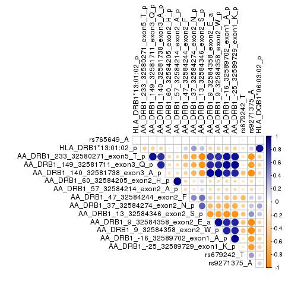

```python
from IPython.display import display
from PIL import Image
corr="Correlation/CorrPlot_LOMG.HLAtypes.vs.GWAShits.jpeg"
display(Image.open(corr))
```

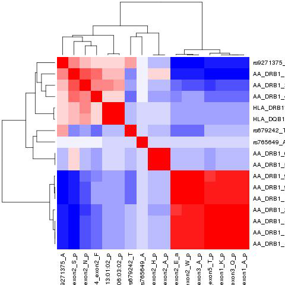

```python
from IPython.display import display
from PIL import Image
corr="Correlation/Heatmap_LOMG.HLAtypes.vs.GWAShits.jpeg"
display(Image.open(corr))
```